# Weather data

Downscaling and extracting weather variables

Author

Kaique Alves

Published

March 4, 2025

## Packages

```r
library(tidyverse)
library(cowplot)
library(patchwork)
library(raster)
library(spatstat)
library(KrigR)
library(lubridate)
library(sf)
library(sp)
library(viridis)
library(ggthemes)
library(terra)
library(MetBrewer)

library(ncdf4)
```

## White mold data

**About the Data**

If you have not downloaded the data necessary to run these analysis, please refer to getting started section before runnig the code below

```r
wm_data = read.csv("data_white-mold/WhiteMoldSurveyWrangledData.csv")
```

### Removing missing coordinates

```r
wm_data2 = wm_data %>%
  filter(!is.na(latitude))
```

### Names of the counties in the dataset

```r
counties = unique(wm_data2$county)
counties
```

```
[1] "Genesee"    "Niagara"    "Orleans"    "Livingston" "Wyoming"
[6] "Ontario"    "Yates"      "Chautauqua" "Monroe"
```

```r
central_ny = c("wyoming", "livingston","ontario","yates")
```

### Ploting the location of each field

```r
#covert the names to lowercase
map_snap_fun = function(yearr){
counties_lc = tolower(counties)

ny_map_data = map_data('county', region = 'new york')

snap_map = ny_map_data %>%
  filter(subregion %in% counties_lc) %>%
  mutate(region2 = case_when(subregion %in% central_ny ~ "Central lakes",
                            !subregion %in% central_ny ~ "Great lakes")) %>%
  ggplot()+
  geom_polygon(data = ny_map_data,
               aes(x=long, y = lat, group = group),
               fill= "white",
               color = "black",
               size =0.3)+
  geom_polygon(aes(x=long, y = lat, group = group,
                   # fill=region2
                   ),
               fill= "#fafced",
               color = "black",
               size =0.3)+
  geom_point(data = wm_data2 %>%
               group_by(subject) %>%
               filter(dap == max(dap),
                       !is.na(wm)) %>%
               ungroup() %>%
               filter(year == yearr) %>%
               arrange(wm),
                size = 1,
             aes(longitude,latitude, color = wm>0))+
  coord_map(xlim = c(-80,-76.7),
            ylim = c(41.8, 43.5))+
  # scale_fill_manual(values = c("gray85", "gray70"))+
  # scale_color_colorblind(labels = c("Absent", "Present"))+
  scale_color_manual(labels = c("Absent", "Present"),
                     values = c("#009E73", "#E69F00"))+
  guides(color = guide_legend(override.aes = list(size=3)),
         fill = "none")+
  theme_minimal()+
  labs(x = "Longitude",
       y = "Latitude",
       fill = "Climate division",
       color = "White mold",
       title = paste(yearr))+
  # facet_wrap(~year, ncol = 1)+
  theme(legend.position = "right",
        legend.text = element_text(size=7),
        axis.title = element_text(size=7),
        axis.text = element_text(size=7),
        plot.title = element_text(size=10))
snap_map
}
```

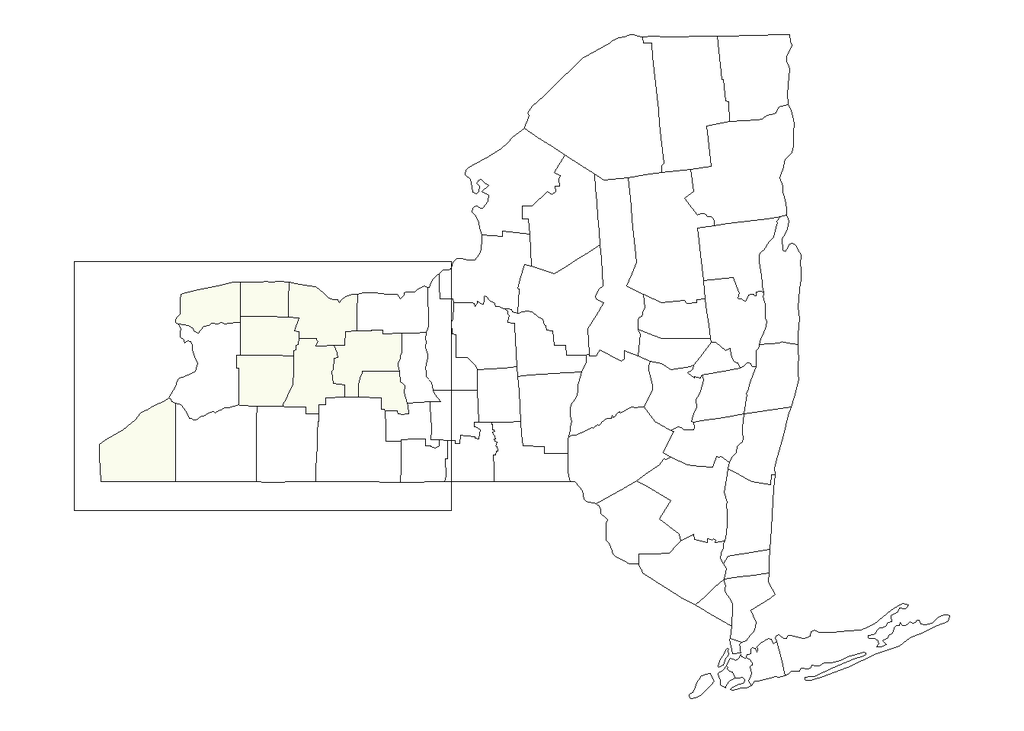

```r
ny_map_data = map_data('county', region = 'new york')
counties_lc = tolower(counties)
ny_map = ny_map_data %>%
  filter(subregion %in% counties_lc) %>%
  mutate(region2 = case_when(subregion %in% central_ny ~ "Central lakes",
                            !subregion %in% central_ny ~ "Great lakes")) %>%
  ggplot()+
  geom_polygon(data = ny_map_data,
               aes(x=long, y = lat, group = group),
               fill= "white",
               color = "black",
               size =0.3
               )+
  geom_polygon(aes(x=long, y = lat, group = group,
                   # fill=region2
                   ),
               fill= "#fafced",
               color = "black",
               size =0.3)+
  annotate("rect", xmin = -80, xmax = -76.5,
                   ymin = 41.8, ymax = 43.5,
           color = "black",
           size = 0.3,
           alpha = 0)+
  # scale_size_manual(values = c(0.1,0.3))+
  # coord_map(xlim = c(-80,-73),
            # ylim = c(40, 45))+
  coord_map()+
   # scale_fill_manual(values = c("gray85", "gray70"))+
  theme_void()+
  labs(x = "Longitude",
       y = "Latitude",
       fill = "Climate division")+
  theme(legend.position = c(0.1,0.8))
ny_map
```

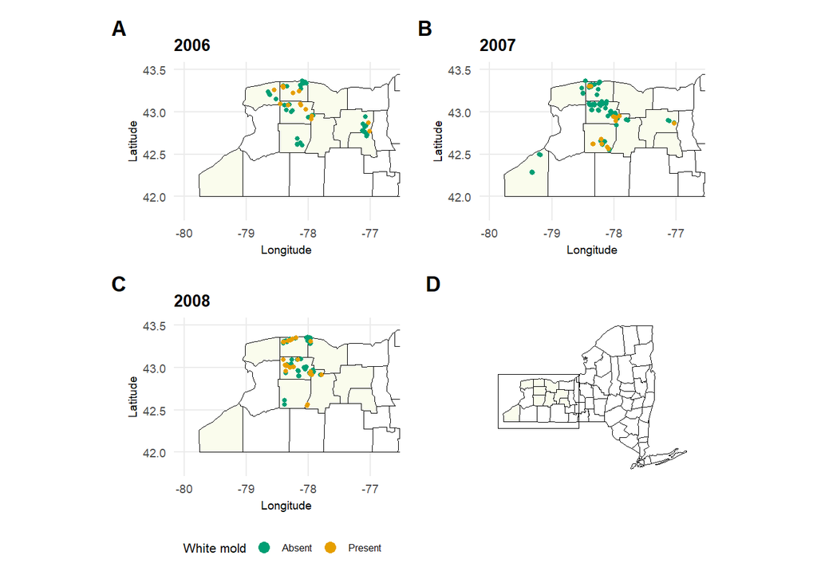

```r
  (map_snap_fun(yearr = "2006") +
   map_snap_fun(yearr = "2007")+
   map_snap_fun(yearr = "2008")+plot_layout(ncol = 2, guides = 'collect')&
     theme(legend.position = "bottom",
           legend.justification = c("left","center"))) +
  (ny_map+plot_layout(guides = 'keep')) +

  # plot_layout(ncol = 2)+
  plot_annotation(tag_levels = "A")&
  theme(legend.text = element_text(size=6),
        legend.title = element_text(size=8),
        legend.key.size = unit(0.4, 'cm'),
        plot.title = element_text(face = "bold"),
        plot.tag = element_text(face = "bold"))
```

```r
ggsave("figs/maps/maps_fields.png", dpi= 900, height = 6, width = 7, bg = "white")
ggsave("figs/maps/maps_fields.pdf", dpi= 900, height = 6, width = 7, bg = "white")
```

## [ERA5](https://confluence.ecmwf.int/display/CKB/The+family+of+ERA5+datasets)

- ERA5-Land hourly data from 1950 to present [Description](https://cds.climate.copernicus.eu/cdsapp#!/dataset/reanalysis-era5-land?tab=overview)
  - 0.1° x 0.1°; Native resolution is 9 km
  - Global
  - Hourly
  - January 1950 to present
- ERA5 hourly data on pressure levels from 1979 to present [Description](https://cds.climate.copernicus.eu/cdsapp#!/dataset/reanalysis-era5-pressure-levels?tab=overview)
  - Reanalysis: 0.25° x 0.25°
  - Global
  - Hourly
  - 1979 to present
- Agrometeorological indicators from 1979 to present derived from reanalysis [Description](https://cds.climate.copernicus.eu/cdsapp#!/dataset/sis-agrometeorological-indicators?tab=overview)
  - 0.1° x 0.1°
  - Global
  - Daily
  - 1979 to present
- There is a package for downloading the data using R: [link](https://bluegreen-labs.github.io/ecmwfr/)

# ERA5-Land hourly data from 1950 to present

Besides there is a package for downloading data from Era5, I chose using their website to download the data. The process, using their website or the R pakage require making a request and waiting a long time to get the data.

These are the codes for each variable inside the `NETCDF` files.

- `u10`, `d2m`, `t2m`, `lai_hv`, `lai_lv`, `src`, `skt`, `stl2`, `sp`, `tp`, `swvl1`, `swvl2`, `swvl3`, `swvl4`

For now, we are going to use only these variables:

- `t2m`: 2m temperature
- `d2m`: 2m dew point temperature
- `sp`: Surface pressure
- `swvl1`: Soil moisture
- `stl1`: Soil temperature

> Relative humidity can be calculated from t2m, d2m, and sp.

## Importing data

Here I load the data for each data variable and gather into a single raster object.

### 2m temperature

```r
t2m_all = raster::stack("data_era5/era5_NY_2006-2008.nc", varname = "t2m")
```

### 2m dewpoint temperature

```r
d2m_all = raster::stack("data_era5/era5_NY_2006-2008.nc", varname = "d2m")
```

### Surface pressure

```r
sp_all = raster::stack("data_era5/era5_NY_2006-2008.nc", varname = "sp")
```

### soil moisture

```r
swvl1_all = raster::stack("data_era5/era5_NY_2006-2008.nc", varname = "swvl1")
```

### soil temperature

```r
stl1_all = raster::stack("data_era5/era5_NY_2006-2008_2.nc", varname = "stl1")
```

## Kringing Test

### Weather data

Here I load the temperature data, select one layer (time and day) and plot it together with the New York map

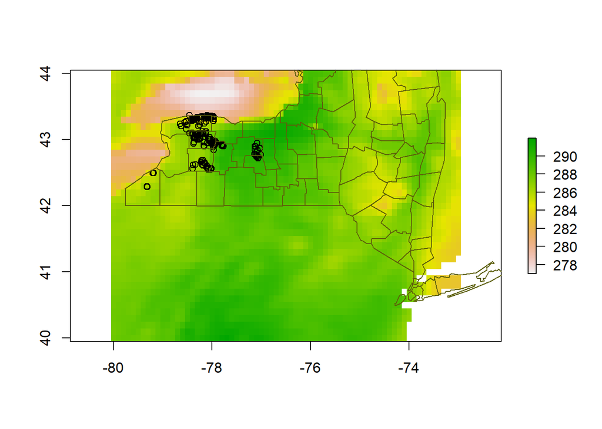

```r
r <- raster::stack("data_era5/era5_NY_2006-2008.nc", varname = "t2m")
# a = r$X2008.05.01.00.00.00
a = subset(r,1)
raster::plot(a)
points(wm_data2$longitude, wm_data2$latitude)
maps::map('county', region = 'new york', col = "#5E610B", add = TRUE)
```

```r
length(names(r))
```

```
[1] 15408
```

### NY shapefile

We will need the New York shapefile to download the digital elevation map, which should be used for kriging. I also filter only the counties that have been surveyed for white mold.

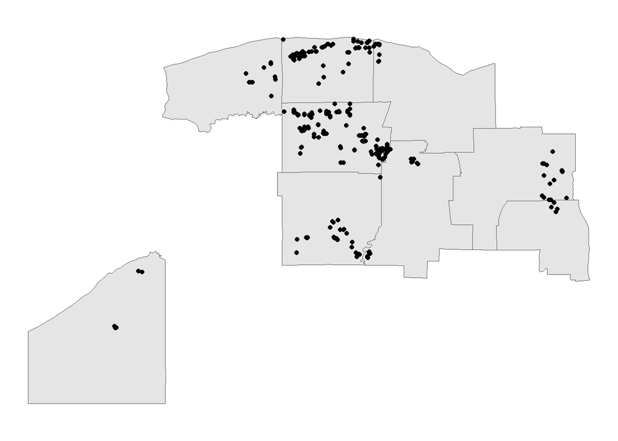

```r
Dir.StateShp <- file.path("data_era5/test")# file.path("shape_files/nc_files")

 # ny_shape1 = readOGR("shape_files/cugir-007865/cugir-007865/cty036.shp")
 ny_shape1 = sf::read_sf("shape_files/cugir-007865/cugir-007865/cty036.shp")

 ny_shape = ny_shape1[ny_shape1$NAME %in% c(unique(wm_data2$county)
                                            # "Yates", "Steuben","Allegany", "Cattaraugus","Erie"
                                            ),]


ggplot()+
  geom_sf(data =ny_shape )+
  geom_point(aes(wm_data2$longitude, wm_data2$latitude))+
  theme_nothing()
```

### Masking

In this section, we create a mask to filter the dataset, retaining only data for the selected counties. The process involves the following steps:

1. Convert the selected county shapes into a simple feature object for visualization.

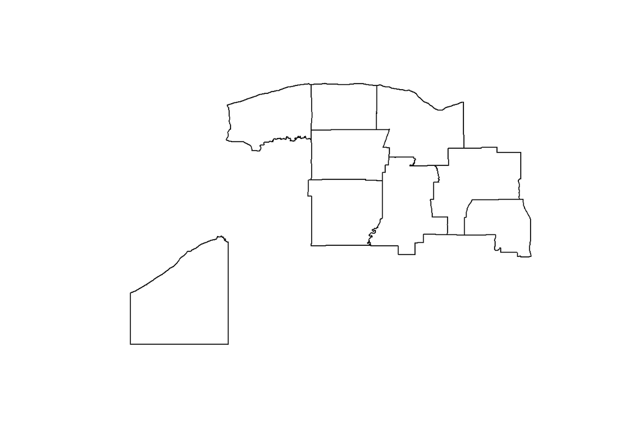

```r
# Create a raster covering the selected counties. Note that all cells has the value 1
ny_shape_st = st_as_sfc(ny_shape[1])
plot(ny_shape_st)
```

2. Merge the geometries to create a single boundary.

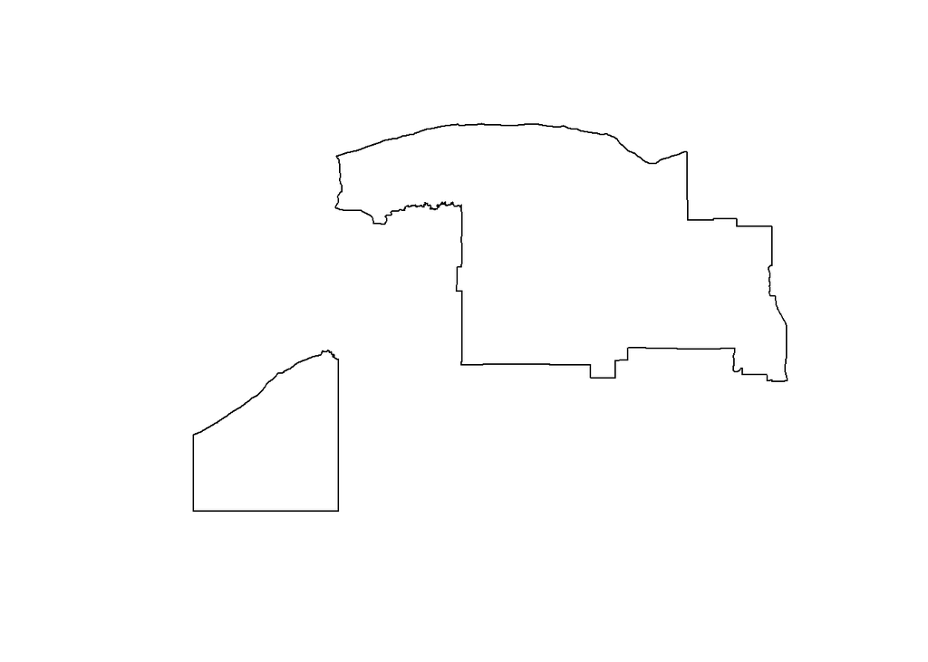

```r
ny_shape_st_nobound = st_union(ny_shape_st)
plot(ny_shape_st_nobound)
```

3. Apply a buffer around the selected area to ensure a smooth mask transition.

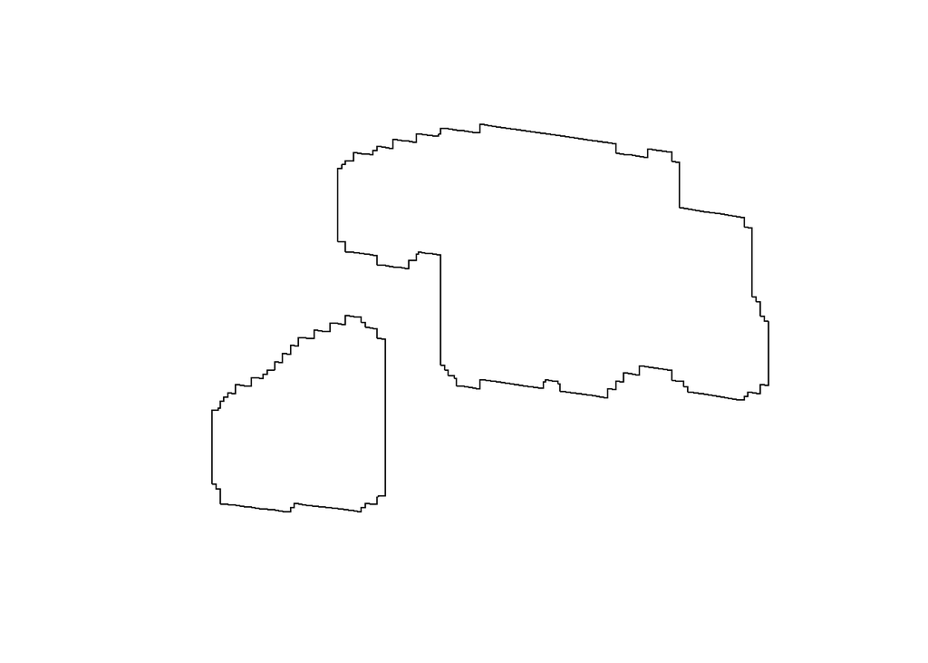

```r
ny_shape_buffer = st_sf(st_buffer(ny_shape_st_nobound,dist = 10000, max_cells = 500))
plot(ny_shape_buffer)
```

4. Use the buffer to mask the raster, setting all selected cells to 1.

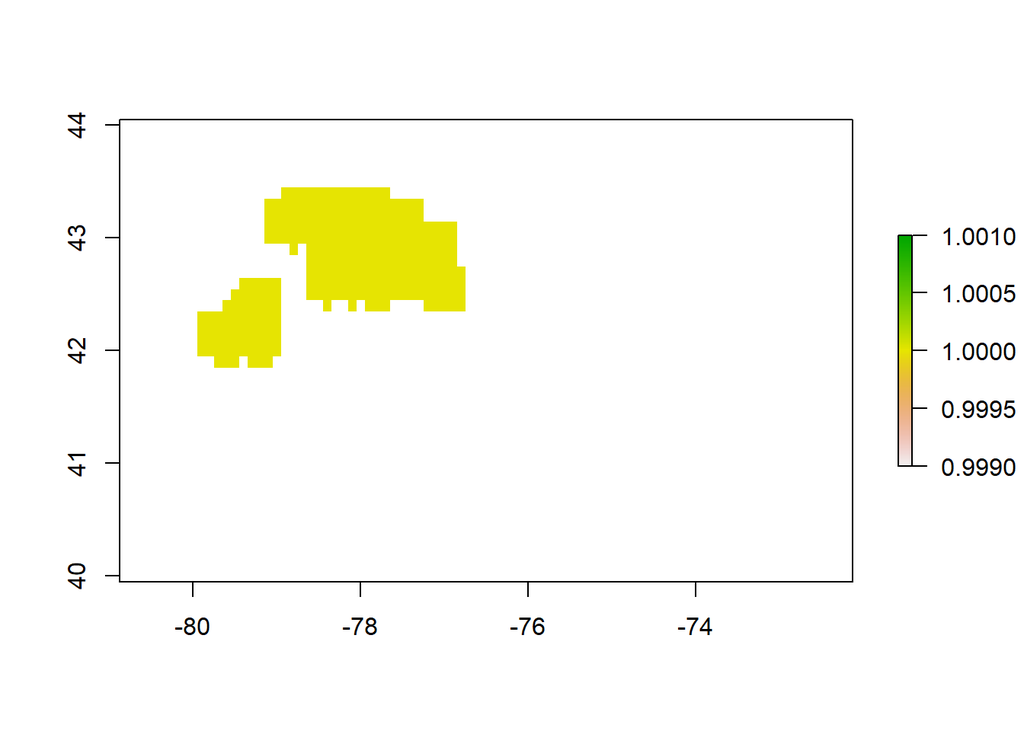

```r
a11 =  terra::mask(a, ny_shape_buffer, updatevalue=NA, touches =T)
a11_values = values(a11)
a11_values[!is.na(values(a11))] = 1
values(a11) = a11_values

plot(a11)
```

5. Convert the masked raster into a polygon. This will serve as the mask for filtering all datasets consistently.

```r
a21 = raster::rasterToPolygons(a11, dissolve=T)
```

6. Apply the mask to filter the raster dataset, ensuring only the relevant regions remain.

```r
a2 = crop(mask(a,a21, touches =T),a21)
```

7. Visualize the results:
   - The first plot shows the initial masked raster.
   - The second plot shows the mask polygon.
   - The third plot displays the filtered raster dataset.

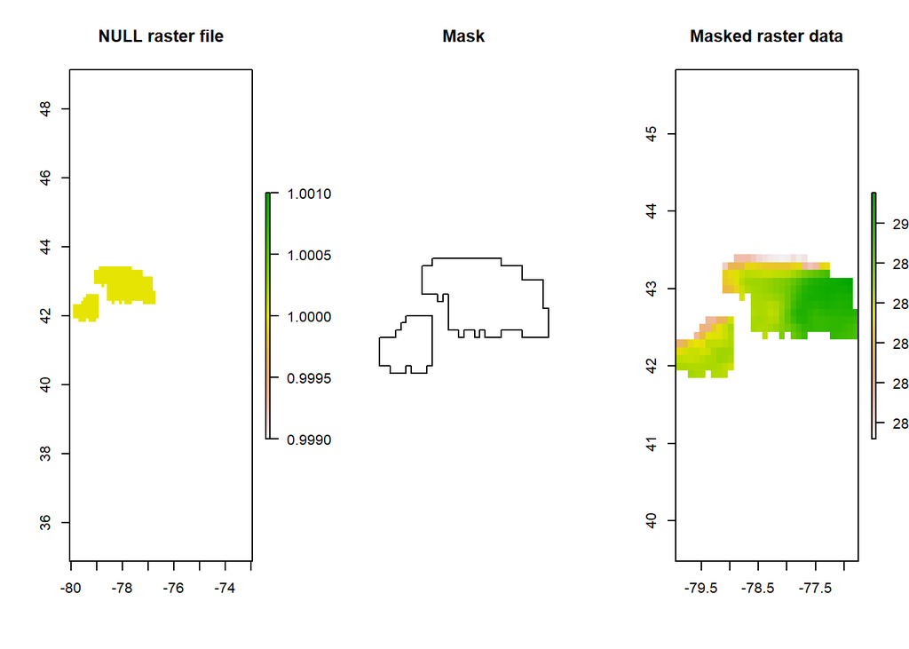

```r
par(mfrow=c(1,3))
plot(a11, main = "NULL raster file")
plot(a21, main = "Mask")
plot(a2, main = "Masked raster data")
```

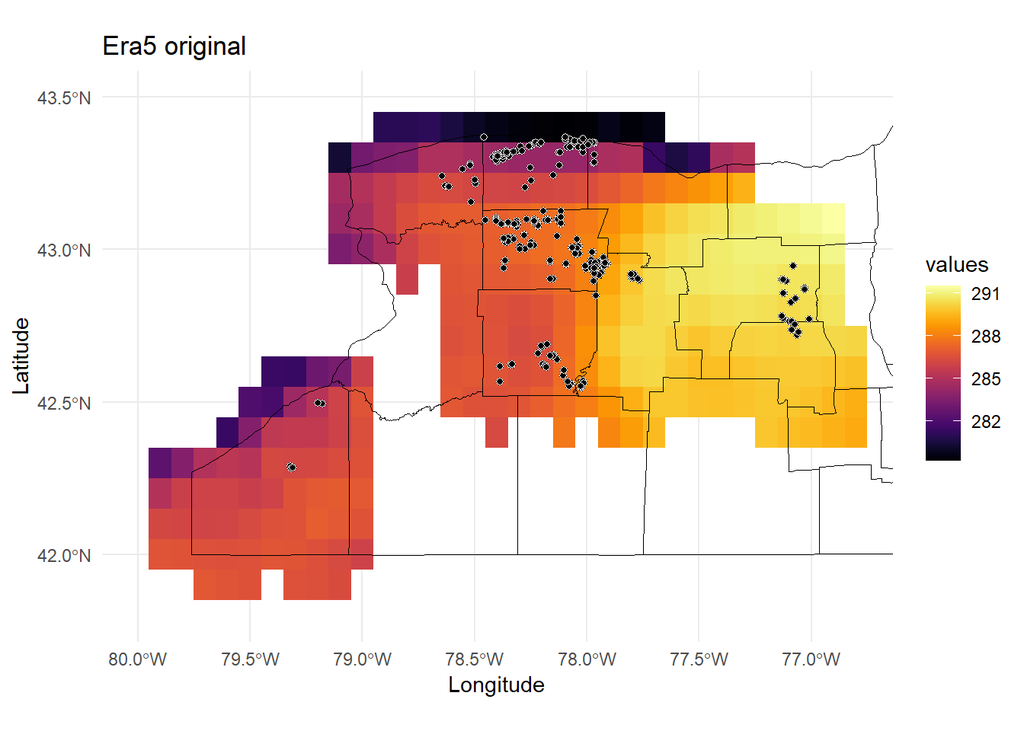

```r
ori_data_df = as.data.frame(a2, xy = T)
colnames(ori_data_df)[3] <- "values"
ori_g= ori_data_df %>%
  filter(!is.na(values)) %>%
  ggplot()+
  geom_tile(aes(x, y, fill = values))+
  geom_sf(data = ny_shape1,
              # aes(x=long, y = lat, group = group),
               fill= NA,
               color = "black")+
  scale_fill_viridis(option="B")+
  coord_sf(xlim = c(-80,-76.8), ylim = c(41.8,43.5))+
  geom_point(data = wm_data2,
             shape = 21,
             color = "white",
             fill = "black",
             aes(longitude,latitude))+
  labs(x = "Longitude",
       y = "Latitude",
       title= "Era5 original")+
  theme_minimal()
ori_g
```

### Downloading Digital elevation model (DEM)

Function to plot the DEM

```r
source("functions/Plot_Covs.R")
```

Downloading DEM

```r
# Covs_ls <- download_DEM(
#   Train_ras = a2,
#   Target_res = .02,
#   Shape = ny_shape,
#   Dir = Dir.StateShp,
#   Keep_Temporary = TRUE
# )

Covs_ls <- CovariateSetup(
  Training =  as(a2, "SpatRaster"),
  Target = .02,
  Extent = a21,
  Dir = "data_era5",
  Keep_Global = TRUE
)
```

```
###### Downloading global covariate data
```

```
[1] "GMTED2010 covariate data already downloaded."
```

```
###### Resampling Data
```

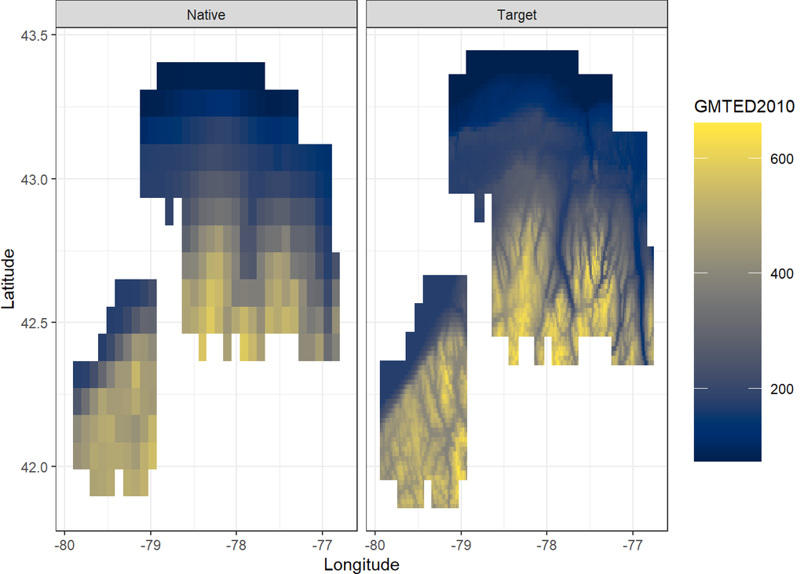

```r
# nc <- nc_open("data_era5/GMTED2010.nc")
# names(nc[['var']])
# Covs_ls = raster::stack(x = "data_era5/GMTED2010.nc", varname = "GMTED2010")
# names(Covs_ls)
# Plot_Covs(Covs_ls)
Plot.Covariates(Covs_ls)
```

```r
# class(a2)
```

##### Visualization

…Using `ggplot2`

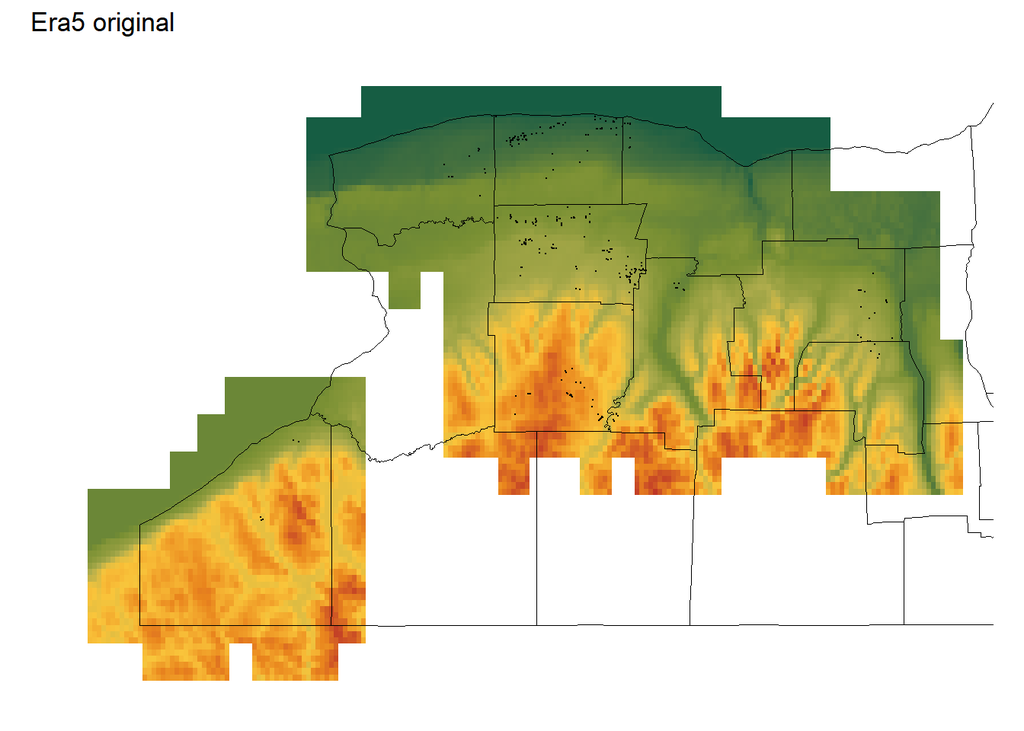

```r
as.data.frame(Covs_ls[[2]], xy = T) %>%
  mutate(DEM = GMTED2010) |>
  filter(!is.na(DEM)) %>%
  ggplot() +
  geom_tile(aes(x,y,fill = DEM))+
  geom_sf(data = ny_shape1,
              # aes(x=long, y = lat, group = group),
               fill= NA,
               color = "black")+
   geom_point(data = wm_data2, size = 0.1,
             aes(longitude,latitude))+
  scale_fill_gradientn(colors=met.brewer("Homer2", direction = -1))+
  coord_sf(xlim = c(-80,-76.8), ylim = c(41.8,43.5))+
  labs(x = "Longitude",
       y = "Latitude",
       title= "Era5 original")+
  theme_void()+
  theme(legend.position = "none")
```

```r
ggsave("figs/maps/elevation.png", dpi = 600, height = 5, width = 7, bg = "white")
```

### Kringing

This function performs kriging of the weather variables as function of the DEM data

```r
a2_SpatRaster = as(a2, "SpatRaster")
KrigStart <- Sys.time()

State_Krig <- Kriging(
  Data =a2_SpatRaster, # what to krig
  Covariates_training  = Covs_ls[[1]], # covariates at training resolution
  Covariates_target  = Covs_ls[[2]], # covariates at target resolution
  Equation = "GMTED2010", # the covariate(s) we want to use
  Keep_Temporary = FALSE, # delete temporary krigs of layers
  nmax = 40, # degree of localisation
  Cores = 1, # we want to krig using three cores to speed this process up
  FileName = "State_Shape", # save the finished file as this _t2m_2008.nc
  Dir = "data_era5/kriging" # where to save the output
)
```

```
###### Checking your Kriging Specification
```

```
[1] "A file with the name State_Shape_Kriged.nc already exists in data_era5/kriging."
[1] "Loading this file for you from the disk."
[1] "A file with the name State_Shape_StDev.nc already exists in data_era5/kriging."
[1] "Loading this file for you from the disk."
```

```r
KrigStop <- Sys.time()
KrigStop-KrigStart
```

```
Time difference of 0.08347392 secs
```

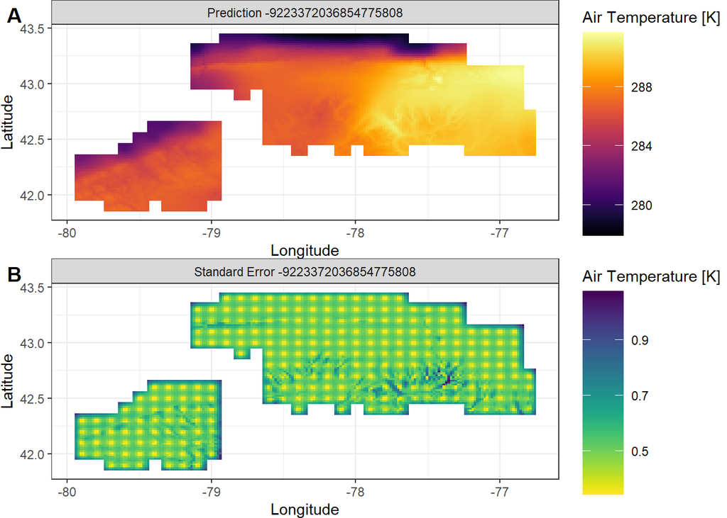

```r
Plot.Kriged(State_Krig)
```

```r
# plot(Covs_ls[[1]])
```

### Visualization

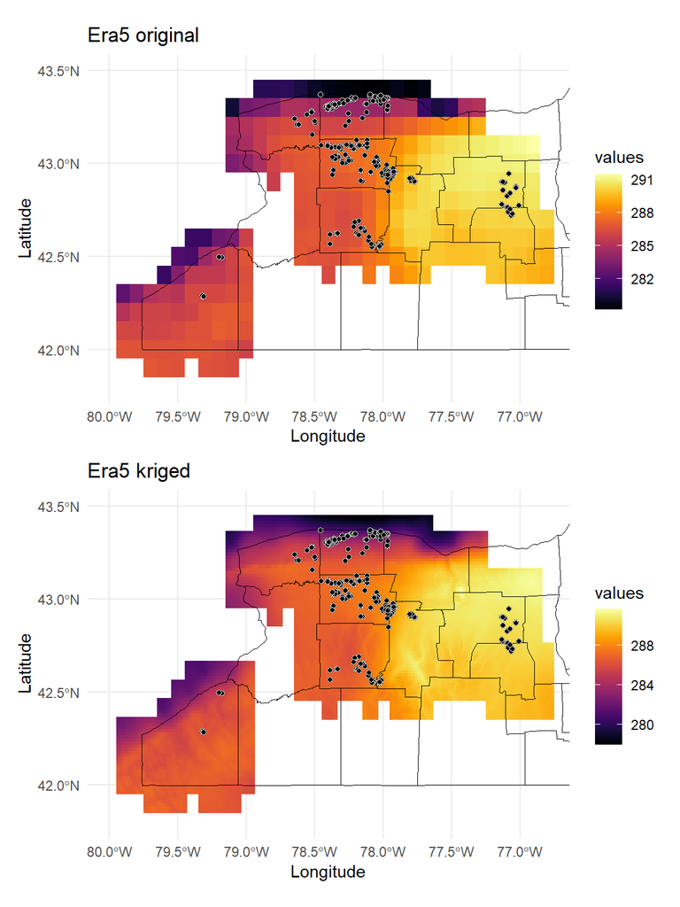

```r
Krigs = State_Krig$Prediction
# Krigs = State_Krig$Kriging_SE
Krig_df <- as.data.frame(Krigs[[1]], xy = TRUE)
colnames(Krig_df)[3] <- "values"



krig_g = Krig_df %>%
  filter(!is.na(values)) %>%
  ggplot()+
  geom_tile(aes(x, y, fill = values))+
  geom_sf(data = ny_shape1,
              # aes(x=long, y = lat, group = group),
               fill= NA,
               color = "black")+
  scale_fill_viridis(option="B")+
  # scale_color_viridis(option="B")+
  geom_point(data = wm_data2,
             shape = 21,
             color = "white",
             fill = "black",
             aes(longitude,latitude))+
  coord_sf(xlim = c(-80,-76.8), ylim = c(41.8,43.5))+
  labs(x = "Longitude",
       y = "Latitude",
       title= "Era5 kriged")

ori_g + krig_g +
  plot_layout(ncol = 1) &
theme_minimal()
```

## Daily summaries

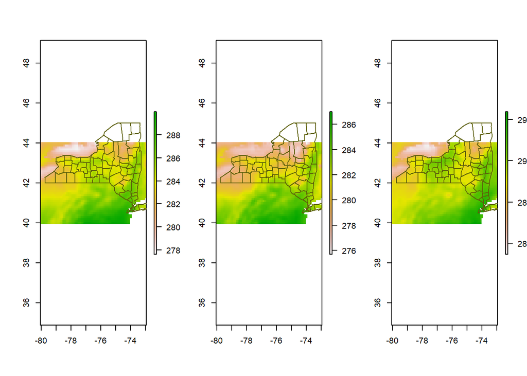

```r
par(mfrow=c(1,3))
plot(mean(t2m_all[[1:24]]))
maps::map('county', region = 'new york', col = "#5E610B", add = TRUE)
plot(min(t2m_all[[1:24]]))
maps::map('county', region = 'new york', col = "#5E610B", add = TRUE)
plot(max(t2m_all[[1:24]]))
maps::map('county', region = 'new york', col = "#5E610B", add = TRUE)
```

```r
# days_in_month(month)
year = 2006:2008
month = 4:10
day = 01:31
hour = as.numeric(seq(0,23,1))
data_era5 = expand_grid(year, month, day) %>%
  dplyr::filter(month != 4 | day != 31,
         month != 6 | day != 31,
         month != 9 | day != 31)%>%
  unite(date, year, month, day,sep="-",remove = F ) %>%
  mutate(date = as.Date(date))
```

Function for calculating the summaries

```r
mean_raster = function(i, stack_obj){
  mean(stack_obj[[i:(i+23)]])
}
min_raster = function(i, stack_obj){
  min(stack_obj[[i:(i+23)]])
}
max_raster = function(i, stack_obj){
  max(stack_obj[[i:(i+23)]])
}
```

### Lapply

```r
days_i = seq(1,length(data_era5$day)*24,by = 24)
time_start = Sys.time()

# dew point
aa1 = lapply(days_i, mean_raster, stack_obj= d2m_all)
d2m_mean_daily_stack = crop(mask(stack(aa1), a21),a21)
writeCDF(rast(d2m_mean_daily_stack),
         "data_era5/daily_summaries/d2m_mean_daily.nc",
         overwrite=TRUE)
# temperature
### mean
aa2 = lapply(days_i, mean_raster, stack_obj= t2m_all)
t2m_mean_daily_stack = crop(mask(stack(aa2), a21),a21)
writeCDF(rast(t2m_mean_daily_stack),
         "data_era5/daily_summaries/t2m_mean_daily.nc",
         overwrite=TRUE)
### minimum
aa3 = lapply(days_i, min_raster, stack_obj= t2m_all)
t2m_min_daily_stack = crop(mask(stack(aa3), a21),a21)
writeCDF(rast(t2m_min_daily_stack),
         "data_era5/daily_summaries/t2m_min_daily.nc",
         overwrite=TRUE)
### maximum
aa4 = lapply(days_i, max_raster, stack_obj= t2m_all)
t2m_max_daily_stack = crop(mask(stack(aa4), a21),a21)
writeCDF(rast(t2m_max_daily_stack),
         "data_era5/daily_summaries/t2m_max_daily.nc",
         overwrite=TRUE)


# Surface pressure
aa5 = lapply(days_i, mean_raster, stack_obj= sp_all)
sp_mean_daily_stack = crop(mask(stack(aa5), a21),a21)
writeCDF(rast(sp_mean_daily_stack),
         "data_era5/daily_summaries/sp_mean_daily.nc",
         overwrite=TRUE)

# Soil moisture
aa6 = lapply(days_i, mean_raster, stack_obj= swvl1_all)
swvl1_mean_daily_stack = crop(mask(stack(aa6), a21),a21)
writeCDF(rast(swvl1_mean_daily_stack),
         "data_era5/daily_summaries/swvl1_mean_daily.nc",
         overwrite=TRUE)

# soil temperature
aa7 = lapply(days_i, mean_raster, stack_obj= stl1_all)
stl1_mean_daily_stack = crop(mask(stack(aa7), a21),a21)
writeCDF(rast(stl1_mean_daily_stack),
         "data_era5/daily_summaries/stl1_mean_daily.nc",
         overwrite=TRUE)

time_end = Sys.time()
time_end -time_start
```

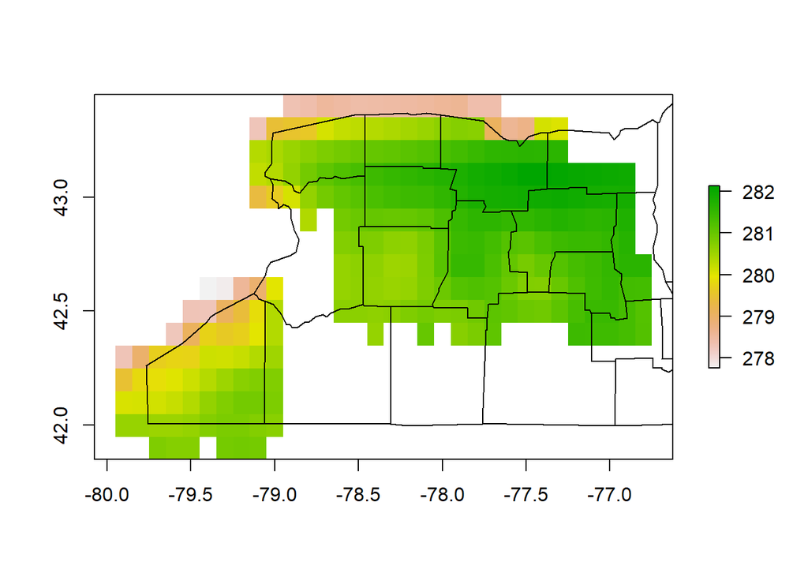

```r
plot(d2m_mean_daily_stack$X1)
# plot(stl1_mean_daily_stack$X1)
maps::map('county', region = 'new york',  add = TRUE)
```

### Kriging the daily summaries

```r
Dir.krigd_var <- file.path("data_era5/kriged")
```

#### Dew point

```r
d2m_mean_daily_Krig = Kriging(
  Data = as(d2m_mean_daily_stack, "SpatRaster"), # what to krig
  Covariates_training  = Covs_ls[[1]], # covariates at training resolution
  Covariates_target  = Covs_ls[[2]], # covariates at target resolution
  Equation = "GMTED2010", # the covariate(s) we want to use
  Keep_Temporary = FALSE, # delete temporary krigs of layers
  nmax = 40, # degree of localisation
  Cores = 5, # we want to krig using three cores to speed this process up
  FileName = "d2m_mean_daily_krig.nc", # save the finished file as this _t2m_2008.nc
  Dir = Dir.krigd_var#"data_era5/kriging" # where to save the output
)
```

#### Mean Temeperature

```r
t2m_mean_daily_Krig = Kriging(
  Data = as(t2m_mean_daily_stack, "SpatRaster"), # what to krig
  Covariates_training  = Covs_ls[[1]], # covariates at training resolution
  Covariates_target  = Covs_ls[[2]], # covariates at target resolution
  Equation = "GMTED2010", # the covariate(s) we want to use
  Keep_Temporary = FALSE, # delete temporary krigs of layers
  nmax = 40, # degree of localisation
  Cores = 5, # we want to krig using three cores to speed this process up
  FileName = "t2m_mean_daily_Krig.nc", # save the finished file as this _t2m_2008.nc
  Dir = Dir.krigd_var#"data_era5/kriging" # where to save the output
)
```

#### Minimum temperature

```r
t2m_min_daily_Krig = Kriging(
  Data = as(t2m_min_daily_stack, "SpatRaster"), # what to krig
  Covariates_training  = Covs_ls[[1]], # covariates at training resolution
  Covariates_target  = Covs_ls[[2]], # covariates at target resolution
  Equation = "GMTED2010", # the covariate(s) we want to use
  Keep_Temporary = FALSE, # delete temporary krigs of layers
  nmax = 40, # degree of localisation
  Cores = 5, # we want to krig using three cores to speed this process up
  FileName = "t2m_min_daily_Krig.nc", # save the finished file as this _t2m_2008.nc
  Dir = Dir.krigd_var#"data_era5/kriging" # where to save the output
)
```

#### Maximum temperature

```r
t2m_max_daily_Krig = Kriging(
  Data = as(t2m_max_daily_stack, "SpatRaster"), # what to krig
  Covariates_training  = Covs_ls[[1]], # covariates at training resolution
  Covariates_target  = Covs_ls[[2]], # covariates at target resolution
  Equation = "GMTED2010", # the covariate(s) we want to use
  Keep_Temporary = FALSE, # delete temporary krigs of layers
  nmax = 40, # degree of localisation
  Cores = 5, # we want to krig using three cores to speed this process up
  FileName = "t2m_max_daily_Krig.nc", # save the finished file as this _t2m_2008.nc
  Dir = Dir.krigd_var#"data_era5/kriging" # where to save the output
)
```

#### Surface pressure

```r
sp_mean_daily_Krig = Kriging(
  Data = as(sp_mean_daily_stack, "SpatRaster"), # what to krig
  Covariates_training  = Covs_ls[[1]], # covariates at training resolution
  Covariates_target  = Covs_ls[[2]], # covariates at target resolution
  Equation = "GMTED2010", # the covariate(s) we want to use
  Keep_Temporary = FALSE, # delete temporary krigs of layers
  nmax = 40, # degree of localisation
  Cores = 5, # we want to krig using three cores to speed this process up
  FileName = "sp_mean_daily_Krig.nc", # save the finished file as this _t2m_2008.nc
  Dir = Dir.krigd_var#"data_era5/kriging" # where to save the output
)
```

#### Soil temperature

```r
stl1_mean_daily_Krig = Kriging(
  Data = as(stl1_mean_daily_stack, "SpatRaster"), # what to krig
  Covariates_training  = Covs_ls[[1]], # covariates at training resolution
  Covariates_target  = Covs_ls[[2]], # covariates at target resolution
  Equation = "GMTED2010", # the covariate(s) we want to use
  Keep_Temporary = FALSE, # delete temporary krigs of layers
  nmax = 40, # degree of localisation
  Cores = 5, # we want to krig using three cores to speed this process up
  FileName = "stl1_mean_daily_Krig.nc", # save the finished file as this _t2m_2008.nc
  Dir = Dir.krigd_var#"data_era5/kriging" # where to save the output
)
```

#### Soil moisture

```r
swvl1_mean_daily_Krig = Kriging(
  Data = as(swvl1_mean_daily_stack, "SpatRaster"), # what to krig
  Covariates_training  = Covs_ls[[1]], # covariates at training resolution
  Covariates_target  = Covs_ls[[2]], # covariates at target resolution
  Equation = "GMTED2010", # the covariate(s) we want to use
  Keep_Temporary = FALSE, # delete temporary krigs of layers
  nmax = 40, # degree of localisation
  Cores = 5, # we want to krig using three cores to speed this process up
  FileName = "swvl1_mean_daily_Krig.nc", # save the finished file as this _t2m_2008.nc
  Dir = Dir.krigd_var#"data_era5/kriging" # where to save the output
)
```

```r
d2m_mean_daily_Krig = stack("data_era5/kriged/d2m_mean_daily_Krig.nc")
t2m_mean_daily_Krig = stack("data_era5/kriged/t2m_mean_daily_Krig.nc")
t2m_min_daily_Krig = stack("data_era5/kriged/t2m_min_daily_Krig.nc")
t2m_max_daily_Krig = stack("data_era5/kriged/t2m_max_daily_Krig.nc")
sp_mean_daily_Krig = stack("data_era5/kriged/sp_mean_daily_Krig.nc")
swvl1_mean_daily_Krig = stack("data_era5/kriged/swvl1_mean_daily_Krig.nc")
stl1_mean_daily_Krig = stack("data_era5/kriged/stl1_mean_daily_Krig.nc")
```

### Ploting the kingued maps (first layer)

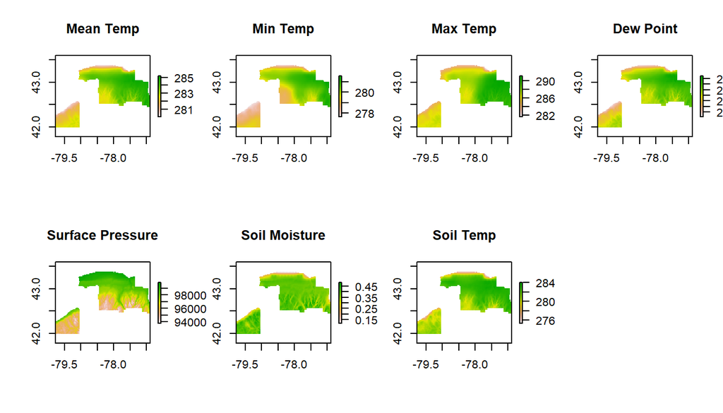

```r
par(mfrow=c(2,4))
plot(t2m_mean_daily_Krig$X1, main = "Mean Temp")
plot(t2m_min_daily_Krig$X1, main = "Min Temp")
plot(t2m_max_daily_Krig$X1, main = "Max Temp")
plot(d2m_mean_daily_Krig$X1, main = "Dew Point")
plot(sp_mean_daily_Krig$X1, main = "Surface Pressure")
plot(swvl1_mean_daily_Krig$X1, main = "Soil Moisture")
plot(stl1_mean_daily_Krig$X1, main = "Soil Temp")
```

Using ggplot

```r
# t2m_max_daily_stack
Krigs = t2m_max_daily_stack$X1
Krig_df <- as.data.frame(Krigs[[1]], xy = TRUE)
colnames(Krig_df)[3] <- "values"

max_t_ori = Krig_df %>%
  filter(!is.na(values)) %>%
  ggplot()+
  geom_sf(data = ny_shape1,
              # aes(x=long, y = lat, group = group),
               fill= "white",
               color = "black")+
  geom_tile(aes(x, y, fill = values-273.15))+
  geom_sf(data = ny_shape1,
              # aes(x=long, y = lat, group = group),
               fill= NA,
               color = "black")+
  scale_fill_viridis(option="B", limits = c(5,18),breaks =seq(5, 18, by = 3))+
  # scale_color_viridis(option="B")+
  geom_point(data = wm_data2,
             shape = 21,
             color = "white",
             fill = "black",
             aes(longitude,latitude))+
  coord_sf(xlim = c(-80,-76.8), ylim = c(41.8,43.5))+
  labs(x = "Longitude",
       y = "Latitude",
       fill = "Max Temperature (°C)",
       title= "Era5 Native Resolution (0.1° x 0.1°)")
# max_t_ori
```

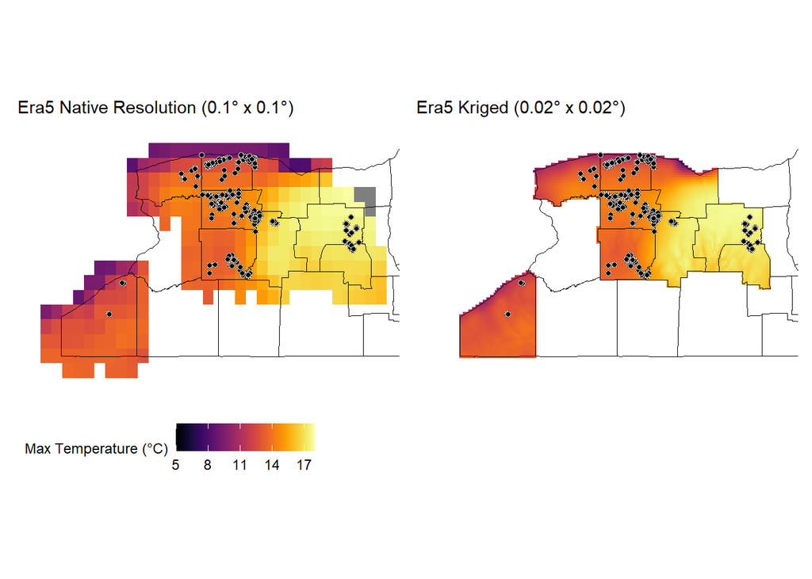

```r
Krigs = t2m_max_daily_Krig$X1
Krig_df <- as.data.frame(Krigs[[1]], xy = TRUE)
colnames(Krig_df)[3] <- "values"



max_t_krig = Krig_df %>%
  filter(!is.na(values)) %>%
  ggplot()+
  geom_sf(data = ny_shape1,
              # aes(x=long, y = lat, group = group),
               fill= "white",
               color = "black")+
  geom_tile(aes(x, y, fill = values-273.15))+
  geom_sf(data = ny_shape1,
              # aes(x=long, y = lat, group = group),
               fill= NA,
               color = "black")+
  scale_fill_viridis(option="B", limits = c(5,18), breaks =seq(5, 18, by = 3))+
  # scale_color_viridis(option="B")+
  geom_point(data = wm_data2,
             shape = 21,
             color = "white",
             fill = "black",
             aes(longitude,latitude))+
  coord_sf(xlim = c(-80,-76.8), ylim = c(41.8,43.5))+
  labs(x = "Longitude",
       y = "Latitude",
       fill = "Max Temperature (°C)",
       title= "Era5 Kriged (0.02° x 0.02°)")

max_t_ori + max_t_krig +
  plot_layout(ncol = 2, guides = "collect") &
  theme_map()&
  theme(legend.position = "bottom",
        legend.text = element_text(size = 9))
```

```r
# ggsave("figs/max_t.png",dpi=900, height = 8, width=14, bg = "white")
```

### Relative humidity

How to calculate relative humidity here [link](https://www.ecmwf.int/sites/default/files/elibrary/2016/17117-part-iv-physical-processes.pdf#subsection.7.4.2) and here [link](https://confluence.ecmwf.int/display/CKB/ERA-Interim%3A+documentation)

$$RH = \frac{es(d2m)}{es(t2m)}*100$$

$es()$ is Saturation vapor pressure and can be calculated as

$$es(T) = \alpha_1*exp( \alpha_3*(\frac{T-t0}{T-\alpha_4}))$$
,

Using these resources, I build the function to calculates RH from Temperature and dew point.

```r
es =function(Temp){
t0 = 273.16

alpha1 = 611.21
alpha3 = 17.502
alpha4 = 32.19

alpha1*exp( alpha3*((Temp-t0)/(Temp-alpha4)))

}

#test
Tdp = 14+273.15
T2m = 31+273.15
es(Tdp)/es(T2m)*100
```

```
[1] 35.55801
```

Creating the raster object of relative humidity

```r
layer_i = 1:nlayers(d2m_mean_daily_Krig)

calculate_RH = function(i, d2m_stack, t2m_stack){
  es(d2m_stack[[i]])/es(t2m_stack[[i]])*100
}

list_rh = lapply(layer_i, calculate_RH, d2m_stack = d2m_mean_daily_Krig,t2m_stack= t2m_mean_daily_Krig)

rh_mean_daily_Krig = brick(list_rh)



writeCDF(rast(rh_mean_daily_Krig),
         "data_era5/kriged/rh_mean_daily_Krig.nc",
         overwrite=TRUE)
```

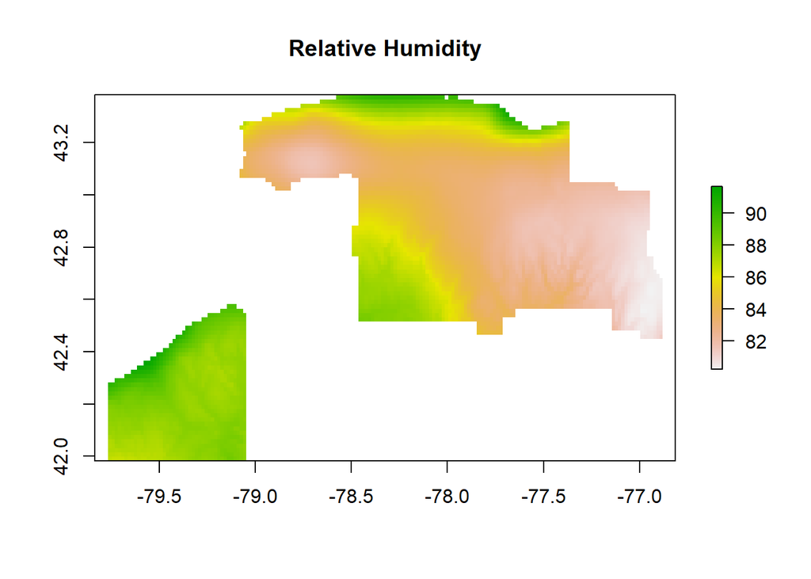

```r
rh_mean_daily_Krig = stack("data_era5/kriged/rh_mean_daily_Krig.nc")
plot(rh_mean_daily_Krig$X1, main = "Relative Humidity")
```

## Extracting data

```r
wm_data2_uni = wm_data2 %>%
  group_by(subject) %>%
  slice(1L)
```

```r
coords<-data.frame(lon=wm_data2_uni$longitude, lat=wm_data2_uni$latitude)
coordinates(coords)<-c("lon","lat")
```

- Dew point

```r
ext_d2m = extract(d2m_mean_daily_Krig, coords)
colnames(ext_d2m) = as.character(data_era5$date)
ext_d2m_coord = cbind(longitude=wm_data2_uni$longitude,
                      latitude=wm_data2_uni$latitude,
                      ext_d2m )

d2m_mean_wm = as.data.frame(ext_d2m_coord) %>%
  mutate(subject =wm_data2_uni$subject) %>%
  pivot_longer(3:644,
               values_to = "d2m",
               names_to = "date")%>%
  mutate(date = as.Date(date))
d2m_mean_wm
```

```
# A tibble: 241,392 × 5
   longitude latitude subject date         d2m
       <dbl>    <dbl>   <int> <date>     <dbl>
 1     -77.9     42.9       1 2006-04-01  282.
 2     -77.9     42.9       1 2006-04-02  271.
 3     -77.9     42.9       1 2006-04-03  276.
 4     -77.9     42.9       1 2006-04-04  270.
 5     -77.9     42.9       1 2006-04-05  266.
 6     -77.9     42.9       1 2006-04-06  272.
 7     -77.9     42.9       1 2006-04-07  275.
 8     -77.9     42.9       1 2006-04-08  268.
 9     -77.9     42.9       1 2006-04-09  268.
10     -77.9     42.9       1 2006-04-10  270.
# ℹ 241,382 more rows
```

- Mean Temperature

```r
ext_t2m_mean = extract(t2m_mean_daily_Krig, coords)
colnames(ext_t2m_mean) = as.character(data_era5$date)
ext_t2m_mean_coord = cbind(longitude=wm_data2_uni$longitude,
                           latitude=wm_data2_uni$latitude,
                           ext_t2m_mean)

t2m_mean_wm = as.data.frame(ext_t2m_mean_coord) %>%
  mutate(subject =wm_data2_uni$subject)%>%
  pivot_longer(3:644,
               values_to = "t2m_mean",
               names_to = "date")%>%
  mutate(date = as.Date(date))
```

- Max Temperature

```r
ext_t2m_max = extract(t2m_max_daily_Krig, coords)
colnames(ext_t2m_max) = as.character(data_era5$date)
ext_t2m_max_coord = cbind(longitude=wm_data2_uni$longitude,
                           latitude=wm_data2_uni$latitude,
                           ext_t2m_max)

t2m_max_wm = as.data.frame(ext_t2m_max_coord) %>%
  mutate(subject =wm_data2_uni$subject)%>%
  pivot_longer(3:644,
               values_to = "t2m_max",
               names_to = "date")%>%
  mutate(date = as.Date(date))
```

- Min Temperature

```r
ext_t2m_min = extract(t2m_min_daily_Krig, coords)
colnames(ext_t2m_min) = as.character(data_era5$date)
ext_t2m_min_coord = cbind(longitude=wm_data2_uni$longitude,
                           latitude=wm_data2_uni$latitude,
                           ext_t2m_min)

t2m_min_wm = as.data.frame(ext_t2m_min_coord) %>%
  mutate(subject =wm_data2_uni$subject)%>%
  pivot_longer(3:644,
               values_to = "t2m_min",
               names_to = "date")%>%
  mutate(date = as.Date(date))
```

- Pressure

```r
ext_sp = extract(sp_mean_daily_Krig, coords)
colnames(ext_sp) = as.character(data_era5$date)
ext_sp_coord = cbind(longitude=wm_data2_uni$longitude,
                      latitude=wm_data2_uni$latitude,
                      ext_sp )

sp_mean_wm = as.data.frame(ext_sp_coord) %>%
  mutate(subject =wm_data2_uni$subject)%>%
  pivot_longer(3:644,
               values_to = "sp",
               names_to = "date")%>%
  mutate(date = as.Date(date))
```

- Soil moisture

```r
ext_sm = extract(swvl1_mean_daily_Krig, coords)
colnames(ext_sm) = as.character(data_era5$date)
ext_sm_coord = cbind(longitude=wm_data2_uni$longitude,
                      latitude=wm_data2_uni$latitude,
                      ext_sm )

sm_mean_wm = as.data.frame(ext_sm_coord)%>%
  mutate(subject =wm_data2_uni$subject) %>%
  pivot_longer(3:644,
               values_to = "sm",
               names_to = "date")%>%
  mutate(date = as.Date(date))
```

- Relative humidity

```r
ext_rh = extract(rh_mean_daily_Krig, coords)
colnames(ext_rh) = as.character(data_era5$date)
ext_rh_coord = cbind(longitude=wm_data2_uni$longitude,
                     latitude=wm_data2_uni$latitude,
                     ext_rh )

rh_mean_wm = as.data.frame(ext_rh_coord)%>%
  mutate(subject =wm_data2_uni$subject)%>%
  pivot_longer(3:644,
               values_to = "rh",
               names_to = "date") %>%
  mutate(date = as.Date(date))
```

- Soil temperature

```r
ext_st = extract(stl1_mean_daily_Krig, coords)
colnames(ext_st) = as.character(data_era5$date)
ext_st_coord = cbind(longitude=wm_data2_uni$longitude,
                     latitude=wm_data2_uni$latitude,
                     ext_st )

st_mean_wm = as.data.frame(ext_st_coord) %>%
  mutate(subject =wm_data2_uni$subject)%>%
  pivot_longer(3:644,
               values_to = "st",
               names_to = "date") %>%
  mutate(date = as.Date(date))
```

Binding data sets

```r
weather_all_wm = d2m_mean_wm %>%
  bind_cols(t2m_mean_wm[,5],
            t2m_max_wm[,5],
            t2m_min_wm[,5],
            sp_mean_wm[,5],
            sm_mean_wm[,5],
            rh_mean_wm[,5],
            st_mean_wm[,5])
weather_all_wm
```

```
# A tibble: 241,392 × 12
   longitude latitude subject date         d2m t2m_mean t2m_max t2m_min     sp
       <dbl>    <dbl>   <int> <date>     <dbl>    <dbl>   <dbl>   <dbl>  <dbl>
 1     -77.9     42.9       1 2006-04-01  282.     284.    289.    281. 97567.
 2     -77.9     42.9       1 2006-04-02  271.     279.    285.    273. 98578.
 3     -77.9     42.9       1 2006-04-03  276.     282.    290.    277. 97387.
 4     -77.9     42.9       1 2006-04-04  270.     277.    284.    273. 97250.
 5     -77.9     42.9       1 2006-04-05  266.     273.    277.    270. 97416.
 6     -77.9     42.9       1 2006-04-06  272.     276.    283.    273. 97868.
 7     -77.9     42.9       1 2006-04-07  275.     278.    281.    275. 97193.
 8     -77.9     42.9       1 2006-04-08  268.     274.    277.    271. 97920.
 9     -77.9     42.9       1 2006-04-09  268.     275.    282.    270. 98859.
10     -77.9     42.9       1 2006-04-10  270.     278.    288.    272. 99093.
# ℹ 241,382 more rows
# ℹ 3 more variables: sm <dbl>, rh <dbl>, st <dbl>
```

### Saving data

```r
data_full = weather_all_wm %>%
  dplyr::select(-latitude, -longitude) %>%
 full_join(wm_data2, by = "subject")

write.csv(data_full, "data_white-mold/data_model_plus_weather.csv",row.names = F)
```

```r
data_full = read.csv("data_white-mold/data_model_plus_weather.csv") %>%
  mutate(date = as.Date(date),
         sampling.date =  as.Date(sampling.date),
         planting.date = as.Date(planting.date))
```

filter between planting and sampling dates

```r
data_fill_filtered = data_full %>%
  filter(date >= (planting.date-30) & date <= sampling.date)
```

```r
write.csv(data_fill_filtered, "data_white-mold/data_model_plus_weather_filtered.csv",row.names = F)
```

```r
data_fill_filtered = read.csv("data_white-mold/data_model_plus_weather_filtered.csv")
```